```python
import numpy as np
import matplotlib.pyplot as plt
import scipy
from scipy import stats, misc

import warnings
warnings.filterwarnings('ignore')

%matplotlib inline
```

**Singular Value Decomposition**

Table of Contents

# 1. Geometry of Linear Maps

Matrix $A$ (or linear transformation) = rotate + stretch/compress

[figure not shown]

an *extremely* important fact:

every matrix $A \in \mathbb{R}^{m \times n}$ maps the unit ball in $\mathbb{R}^n$ to an ellipsoid in $\mathbb{R}^m$

$$\begin{align*} S &= \{ x \in \mathbb{R}^n \mid \; \Vert x \Vert \leq 1 \}\\ AS &= \{Ax \mid x\in \mathbf{S}\}\end{align*}$$

# 2. Singular Values and Singular Vectors

- the numbers $\sigma_1, \cdots, \sigma_n$ are called the *singular values* of $A$ by convention, $\sigma_i > 0$
- the vectors $u_1, \cdots, u_n$ these are unit vectors along the principal semiaxes of $AS$
- the vectors $\upsilon_1, \cdots, \upsilon_n$ these are the preimages of the principal semiaxes, defined so that $$ A\upsilon_i = \sigma_i u_i$$

## 2.1. Graphical Understanding

[figure not shown]

$$\begin{align*} A\begin{bmatrix} \upsilon_1& \upsilon_2 & \cdots & \upsilon_r \end{bmatrix} & =\begin{bmatrix} A\upsilon_1 & A\upsilon_2 & \cdots & A\upsilon_r \end{bmatrix} \\ & =\begin{bmatrix} \sigma_1u_1& \sigma_2u_2 & \cdots & \sigma_ru_r \end{bmatrix} \\ & =\begin{bmatrix} u_1& u_2 & \cdots & u_r \end{bmatrix}\begin{bmatrix} \sigma_1& & & \\ & \sigma_2 & & \\ & & \ddots & \\ & & & \sigma_r \end{bmatrix} \\ \\ \therefore \; AV & = U\Sigma \quad (r \leq m, n) \end{align*}$$

## 2.2. Thin Singular Value Decomposition

We have $A \in \mathbb{R}^{m \times n}$, skinny and full rank (*i.e.*, $r = n$), and

$$A\upsilon_i = \sigma_i u_i \quad \text{for } 1 \leq i \leq n$$

let

$$\hat U = \begin{bmatrix}u_1 & u_2 & \cdots & u_n \end{bmatrix}, \quad \hat \Sigma = \begin{bmatrix}\sigma_1& & & \\ & \sigma_2 &&\\ &&\ddots&\\ &&&\sigma_n \end{bmatrix}, \quad V = \begin{bmatrix} \upsilon_1 & \upsilon_2 & \cdots & \upsilon_n \end{bmatrix} $$

in matrix form, the above equation is $AV = \hat U \hat \Sigma$ and since $V$ is orthogonal

$$ A = \hat U \hat \Sigma V^T $$

called the *thin (or reduced) SVD* of $A$

[figure not shown]

## 2.3. Full Singular Value Decomposition

We can add extra orthonormal columns to $U$ to make an orthogonal matrix $(m \geq n)$

$$ U = \begin{bmatrix} u_1 & u_2 & \cdots & u_m \end{bmatrix}$$

We also add extra rows of zeros to $\hat \Sigma$, so

$$ A = U\Sigma V^T$$

[figure not shown]

this is the *(full) singular value decomposition* of $A$

> Every matrix $A$ has a singular value decomposition.

> If $A$ is not full rank, then some of the diagonal entries of $\Sigma$ will be zero

## 2.4. SVD - Matrix factorization

- for any matrix A $$ A = U\Sigma V^T $$
- for symmetric and positive definite matrix A

$$A = S\Lambda S^{-1} = S\Lambda S^T\quad (S: \text{eigenvectors})$$

## 2.5. Interpretation of SVD

[figure not shown]

The SVD decomposes the linear map into

- *rotate* by $V^T$
- *diagonal scaling* by $\sigma_i$
- *ratate* by $U$

Note that, unlike the eigen-decomposition, input and output directions are different

## 2.6. Example

$$\begin{array}{Icr} A = \begin{bmatrix} 4 & 4 \\ -3 & 3 \end{bmatrix} \end{array} \quad \quad \begin{array}{Icr} \begin{align*} &\textbf{orthonormal basis} \\ &\upsilon_1, \upsilon_2 \text{ in row space } \mathbb{R}^2 \\ &u_1, u_2 \text{ in column space } \mathbb{R}^2 \\ &\sigma_1 > 0 \\ &\sigma_2 > 0 \end{align*} \end{array} $$

$$ \begin{array}{lcr} A\upsilon_1 = \sigma_1 u_1\\ A\upsilon_2 = \sigma_2 u_2 \end{array} \; \implies \; \begin{array}{lcr} AV = U\Sigma \\ A = U\Sigma V^{-1} = U\Sigma V^T \end{array}$$

1) $A^TA$: (small) positive definite & symmetric

$$V\Sigma^TU^TU\Sigma V^T = V\Sigma^T\Sigma V^T = V\begin{bmatrix} \sigma_1^2& & \\ & \sigma_2^2 & \\ & & \ddots \\ \end{bmatrix}V^T$$

```python
A = np.array([[4, 4], [-3, 3]])
[D, V] = np.linalg.eig(A.transpose().dot(A))

print (V)

print (D)
```

```
[[ 0.70710678 -0.70710678]
 [ 0.70710678  0.70710678]]
[ 32.  18.]
```

2) $AA^T$: (large) positive definite & symmetric

$$U\Sigma V^TV\Sigma^TU^T = U\Sigma\Sigma^TU^T = U\begin{bmatrix} \sigma_1^2& & \\ & \sigma_2^2 & \\ & & \ddots \\ \end{bmatrix}U^T$$

```python
A = np.array([[4, 4], [-3, 3]])
[D, U] = np.linalg.eig(A.dot(A.transpose()))

print (U)
print (D)
```

```
[[ 1.  0.]
 [ 0.  1.]]
[ 32.  18.]
```

```python
[U, S, V] = np.linalg.svd(A)
print (U)
print (S)
print (V)
```

```
[[-1.  0.]
 [ 0.  1.]]
[ 5.65685425  4.24264069]
[[-0.70710678 -0.70710678]
 [-0.70710678  0.70710678]]
```

# 3. PCA and SVD

- Any real symmetric and positive definite matrix B has a eigen decomposition

$$B = S\Lambda S^T$$

- A real matrix $(m\times n)$ A, where $m>n$, has the decompsition

$$A = U\Sigma V^T$$

- From A (skinny and full rank) we can construct two positive-definite symmetric matrices, $AA^T$ and $A^TA$

$$\begin{align*} AA^T &= U\Sigma V^T V \Sigma^T U^T = U \Sigma \Sigma^T U^T \quad (m \times m, \,n\, \text{eigenvalues and }\, m-n \; \text{zeros},\; U\; \text{eigenvectors})\\ A^TA &= V \Sigma^T U^T U\Sigma V^T = V \Sigma^T \Sigma V^T \quad (n \times n, \,n \;\text{eigenvalues},\; V\; \text{eigenvectors}) \end{align*}$$

- PCA by SVD $$B = A^TA = V \Sigma^T \Sigma V^T = V \Lambda V^T$$
  - $V$ is eigenvectors of $B = A^TA$
  - $\sigma_i^2 = \lambda_i$
  - Note that in PCA, $$ VS V^T \quad \left(\text{where }S = \frac{1}{m}X^TX = \left(\frac{X}{\sqrt{m}}\right)^T \frac{X}{\sqrt{m}} \right)$$

# 4. Low Rank Approximation: Dimension Reduction

## 4.1. Low Rank Approximation

- in 2D case

$$\begin{align*} x & = c_1 \upsilon_1 + c_2 \upsilon_2 \\ & = \langle x, \upsilon_1 \rangle \upsilon_1 + \langle x, \upsilon_2 \rangle \upsilon_2\\ & = ( \upsilon_1^{T} x) \upsilon_1 + ( \upsilon_2^T x) \upsilon_2 \end{align*}$$

$$\begin{align*} Ax & = c_1A \upsilon_1 + c_2 A \upsilon_2 \\ & = c_1\sigma_1 u_1 + c_2 \sigma_2 u_2 \\ & = u_1 \sigma_1 \upsilon_1^Tx + u_2\sigma_2 \upsilon_2^T x \approx u_1\sigma_1 \upsilon_1^Tx \quad (\text{if } \sigma_1 \gg \sigma_2)\\ \\ & = \begin{bmatrix} u_1 & u_2 \end{bmatrix}\begin{bmatrix}\sigma_1 & 0\\ 0 & \sigma_2 \end{bmatrix}\begin{bmatrix} \upsilon_1^T \\ \upsilon_2^T \end{bmatrix} x \\ \\ & = U \Sigma V^Tx \approx u_1\sigma_1 \upsilon_1^Tx \quad (\text{if } \sigma_1 \gg \sigma_2) \end{align*}$$

- Low rank approximation of matrix A in general $$\begin{align*} A &= U_r \Sigma_r V_r^T = \sum_{i=1}^{r}\sigma_i u_i \upsilon_i^T\\ \tilde A &= U_k \Sigma_k V_k^T = \sum_{i=1}^{k}\sigma_i u_i \upsilon_i^T \qquad (k \leq r)\end{align*}$$

## 4.2. Least Squares and SVD

- Consider $$ \min_x \, \lVert Ax - b \rVert _2^2$$
- Let $A = U\Sigma V^T$
- Using the orthogonality of $U$ and $V$ we have

$$ \lVert Ax - b \rVert _2^2 = \lVert U^T (AVV^Tx - b) \rVert _2^2 = \lVert \underbrace{\Sigma}_{\text{diagonal}} \underbrace{V^Tx}_{z}-U^Tb \rVert_2^2 = \sum_{i=1}^{r} \left( \sigma_i z_i - u_i^T b \right)^2 + \sum_{i=r+1}^{m} (u_i^Tb)^2$$

- The (minimum norm) solution of $ \min_x \, \lVert Ax - b \rVert _2^2$ is given

$$ \begin{align*} z_i &= \begin{cases} \frac{u_i^T b}{\sigma_i} & \quad i=1,\cdots,r\\ 0 & \quad i = r+1,\cdots,n \end{cases}\\ x &= Vz \\ x &= \sum_{i=1}^{r}\frac{u_i^T b}{\sigma_i} \upsilon_i \end{align*}$$

[figure not shown]

## 4.3. Regularized Least Squares and SVD

$$ \min_{x} \;\lVert Ax - b\rVert_2^2 + \lambda \lVert x \rVert_2^2 = \min_x \,\Bigg\Vert \begin{bmatrix} A\\ \sqrt{\lambda}I \end{bmatrix} x - \begin{bmatrix} b\\ 0 \end{bmatrix} \Bigg\Vert^2_{2} $$$$\begin{align*} \left( A^T A + \lambda I \right) x &= A^T b \\ \left( V\Sigma^T U^T U\Sigma V^T + \lambda V V^T \right) x &= V\Sigma^T U^T b \\ V \left( \Sigma^T \Sigma + \lambda I\right)V^T x &= V\Sigma^T U^T b \\ \left( \Sigma^T \Sigma + \lambda I\right)V^T x &= \Sigma^T U^T b \qquad (V^Tx = z)\\ \underbrace{\left( \Sigma^T \Sigma + \lambda I\right)}_{\text{diagonal}}z &= \Sigma^T U^T b \end{align*} $$

- The (minimum norm) solution is given

$$ \begin{align*} z_i &= \begin{cases} \frac{\sigma_i (u_i^T b)}{\sigma_i^2 + \lambda} & \quad i=1,\cdots,r\\ 0 & \quad i = r+1,\cdots,n \end{cases}\\ x &= Vz \\ x &= \sum_{i=1}^{r}\frac{\sigma_i (u_i^T b)}{\sigma_i^2 + \lambda} \upsilon_i = \sum_{i=1}^{r}\frac{u_i^T b}{\sigma_i + \frac{\lambda}{\sigma_i }} \upsilon_i \end{align*}$$

# 5. Example

```python
A =np.array([[11.08,   6.82,    1.76 , -6.82],
      [2.50,  -1.01 ,  -2.60 ,  1.19],
     [-4.88,  -5.07  , -3.21 ,  5.20],
     [-0.49,   1.52   , 2.07 , -1.66],
    [-14.04,  -12.40 , -6.66 , 12.65],
      [0.27 , -8.51 , -10.19 ,  9.15],
      [9.53 , -9.84 , -17.00 , 11.00],
    [-12.01,   3.64 ,  11.10 , -4.48]])

[U,S,V] = np.linalg.svd(A)
print ("U = \n", U)

print ("S = \n", S)

print ("V = \n", V)
```

```
U =
 [[-0.24642369  0.44536234  0.6205749   0.32739909  0.45915182  0.05410587
  -0.18650735  0.00956801]
 [ 0.07432183  0.10750102  0.28337342 -0.77803389 -0.10352762  0.32547077
  -0.42245245  0.04655432]
 [ 0.21369502 -0.1903207   0.49492174  0.11043549 -0.4736735  -0.61498898
  -0.24132713 -0.01233476]
 [-0.08223154 -0.02472167  0.20057294  0.06152361 -0.27047805  0.29819169
   0.20131309 -0.86371786]
 [ 0.50375686 -0.55378628  0.13739629 -0.02351069  0.61002316  0.01682912
  -0.07593043 -0.20479838]
 [ 0.43719294  0.03496575 -0.05496539  0.50172005 -0.29664823  0.55199001
  -0.3572128   0.18055856]
 [ 0.59019451  0.42657675  0.21078205 -0.13667122 -0.03298713 -0.00394525
   0.6243326   0.1252985 ]
 [-0.2967926  -0.51321848  0.42787997  0.0231769  -0.14042827  0.34499254
   0.40598717  0.40166774]]
S =
 [  3.68258450e+01   2.62368811e+01   2.20213307e-02   5.10429562e-03]
V =
 [[-0.03564832 -0.5381828  -0.61426544  0.5759917 ]
 [ 0.92076022  0.16617467 -0.32597333 -0.13538086]
 [-0.13920696 -0.49222525 -0.31155848 -0.80079151]
 [-0.36269992  0.66367127 -0.6475729  -0.09294376]]
```

**Question**

How to determine a good $k$ so that we can efficiently compress $A$ without losing too much information of $A$?

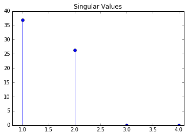

```python
%matplotlib inline
sig_val = S
sig_val = sig_val[0:4]
plt.stem(range(1,5),sig_val)
plt.xlim([0.8, 4.1])
plt.title('Singular Values')
plt.show()
```

```python
k = 2

#V is not equal the result of matlab SVD
# V_python = transpose(V_matlab)

low_U = U[:,0:k]
low_S = np.diag(S[0:k])
low_V = V[0:k,:]
```

```python
A_approx = (low_U.dot(low_S)).dot(low_V)
A_approx
```

```
array([[ 11.08250851,   6.8256176 ,   1.76533991,  -6.80890115],
       [  2.49942829,  -1.00429274,  -2.60062751,   1.19462804],
       [ -4.87827835,  -5.06500943,  -3.20623934,   5.20878009],
       [ -0.48927124,   1.52196569,   2.07157948,  -1.65643381],
       [-14.03962233, -12.39843105,  -6.65913505,  12.65241176],
       [  0.27076035,  -8.51229541, -10.18871873,   9.14926874],
       [  9.53039313,  -9.83725225, -16.99900559,  11.0036522 ],
       [-12.00864542,   3.64455947,  11.10301226,  -4.47244356]])
```

## 5.1. Example : Image Approximation

- Learn how to reduce the amount of storage needed for an image using the singular value decomposition.
- Approximation of $A$

$$\tilde A = U_k \Sigma_k V_k^T = \sum_{i=1}^{k}\sigma_i u_i \upsilon_i^T \qquad (k \leq r)$$

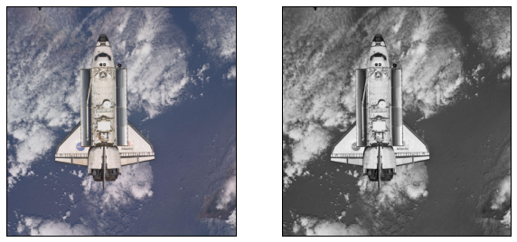

```python
%matplotlib inline
im = misc.imread('./image_files/SpaceShuttle_01.jpg')
suqered_im = im[:, 0:2800, :]
w = misc.imresize(suqered_im, [400,400])

def rgb2gray(rgb):
    return np.dot(rgb[...,:3], [0.299, 0.587, 0.114])

g = rgb2gray(w)
fig = plt.figure(figsize = (10, 10))
ax = fig.add_subplot(1, 2, 1, xticks = [], yticks = [])
ax.imshow(w)
ax = fig.add_subplot(1, 2, 2, xticks = [], yticks = [])
ax.imshow(g, cmap = plt.get_cmap('gray'))
plt.show()
```

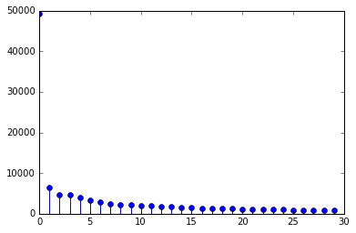

```python
U,S,V = np.linalg.svd(g)
matS=np.diag(S)

%matplotlib inline
plt.stem(S[0:30])
plt.show()
```

**Approximated image when k = 30**

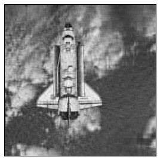

```python
%matplotlib inline
k = 30 # low rank approximation

low_U = U[:, 0:k]
low_S = matS[0:k, 0:k]
low_V = V[0:k, :]

A_approx = (low_U.dot(low_S)).dot(low_V)
fig = plt.figure(figsize = (10, 10))
ax = fig.add_subplot(1, 2, 1, xticks = [], yticks = [])
ax.imshow(A_approx, cmap = plt.get_cmap('gray'))
plt.show()
```

**Approximated images with k varied**

[figure not shown]

```python
def plot_svd_rank(k = 15):
    low_U = U[:, 0:k]
    low_S = matS[0:k, 0:k]
    low_V = V[0:k, :]

    A_approx = (low_U.dot(low_S)).dot(low_V)

    fig = plt.figure(figsize = (5, 5))
    ax = fig.add_subplot(1, 1, 1, xticks = [], yticks = [])
    ax.imshow(A_approx, cmap = plt.get_cmap('gray'))

    plt.title('rank'+ str(k))
    plt.show()


%matplotlib inline
from IPython.html.widgets import interact
interact(plot_svd_rank, k = [1, 400, 10]);
```

## 5.2. Reduce Noise in a Dataset

**Create the initial mesh**

```python
[X, Y] = np.meshgrid(np.arange(0, 3*np.pi/2, np.pi/30), np.arange(0, 3*np.pi/2, np.pi/30))
Z = np.sin(X*Y*np.pi/3)
```

**Plot initial (exact) data**

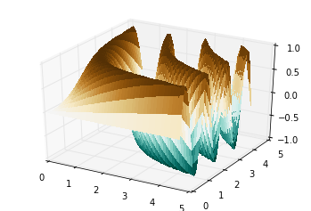

```python
%matplotlib inline
from mpl_toolkits.mplot3d import Axes3D
from matplotlib import cm
fig = plt.figure()
ax = fig.gca(projection='3d')
surf = ax.plot_surface(X, Y, Z, rstride=1, cstride=1, cmap=cm.BrBG_r,
                       linewidth=0, antialiased=False)
plt.show()
```

**Induce noise**

```python
maxNoise = 0.1
[nRows, nCols] = np.shape(Z)
noise = 2*maxNoise*np.random.rand(nRows,nCols) - maxNoise
Znoise = Z + noise
```

**Plot noisy data**

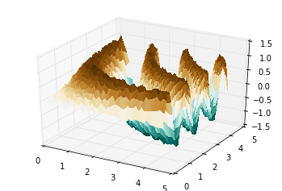

```python
%matplotlib inline
fig = plt.figure()
ax = fig.gca(projection='3d')
surf = ax.plot_surface(X, Y, Znoise, rstride=1, cstride=1, cmap=cm.BrBG_r,
                       linewidth=0, antialiased=False)
plt.show()
```

**Perform SVD**

```python
[U,S,V] = np.linalg.svd(Znoise,0);
```

**Plot the singular values**

```
(0, 15)
```

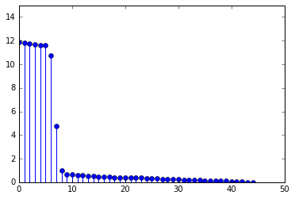

```python
%matplotlib inline
plt.stem(S)
plt.xlim([0, 50])
plt.ylim([0, 15])
```

**Form rank-k approximation**

```python
k = 8

Znoiseless = (U[:,0:k].dot(np.diag(S[0:k]))).dot(V[0:k,:])
```

**Plot rank-k approximation**

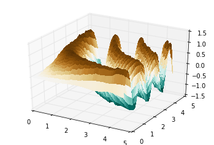

```python
%matplotlib inline
fig = plt.figure()
ax = fig.gca(projection='3d')
surf = ax.plot_surface(X, Y, Znoiseless, rstride=1, cstride=1, cmap=cm.BrBG_r,
                       linewidth=0, antialiased=False)
plt.show()
```

**All plots**

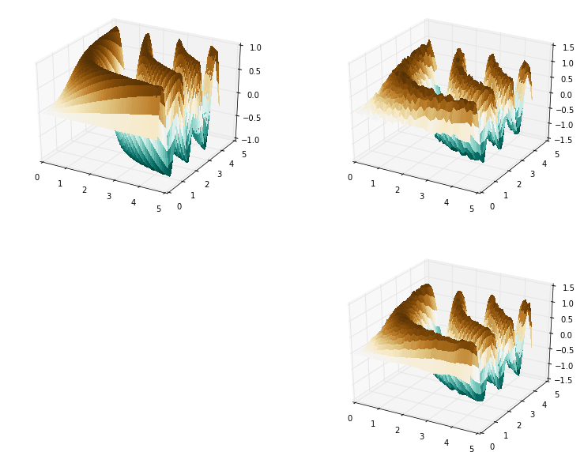

```python
%matplotlib inline
fig = plt.figure(figsize = (13, 10))
ax = fig.add_subplot(2, 2, 1, projection='3d')
surf = ax.plot_surface(X, Y, Z, rstride=1, cstride=1, cmap=cm.BrBG_r,
                       linewidth=0, antialiased=False)

ax = fig.add_subplot(2, 2, 2, projection='3d')
surf = ax.plot_surface(X, Y, Znoise, rstride=1, cstride=1, cmap=cm.BrBG_r,
                       linewidth=0, antialiased=False)

ax = fig.add_subplot(2, 2, 4, projection='3d')
surf = ax.plot_surface(X, Y, Znoiseless, rstride=1, cstride=1, cmap=cm.BrBG_r,
                       linewidth=0, antialiased=False)

plt.show()
```